# EDA: Chicago School Performance

2025-02-28

## Chicago Schools

This dataset includes a year’s worth of data regarding Chicago school performance. Included are a variety of scores for aspects like the school’s safety, environmental features, teacher performance, and parent involvement, both in numeric and categorical varieties. Below, we explore the potential correlation between a few of these scores.

```r
# load in dataset of choice
cs <- read.csv("chicago_schools.csv")
```

#### Yearly Progress Tied to Teacher Scores

Unsurprisingly, there seems to be a correlation between how teachers were scored categorically and what percent of schools met the threshold for meeting the Adequate Yearly Progress threshold. It is worth noting, however, that even for schools with Very Strong teacher scores, roughly 2/3 of schools still did not meet this threshold.

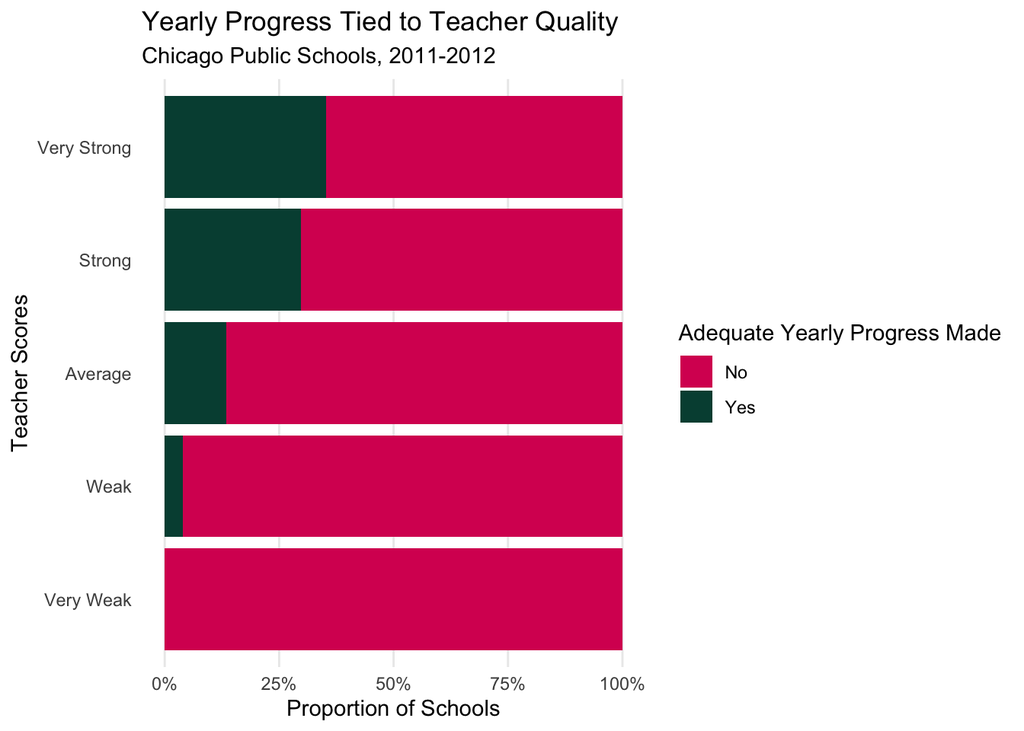

```r
# remove instances where data is removed for privacy reasons
q8 <- cs %>%
  filter(teachers_icon != "NDA" & adequate_yearly_progress_made != "NDA")
# store categorical values for customizing axes
scores <- c("Very Weak", "Weak", "Average", "Strong", "Very Strong")

ggplot(q8, aes(y=teachers_icon, fill=adequate_yearly_progress_made)) +
  geom_bar(position="fill") +
  labs(y="Teacher Scores", x="Proportion of Schools", title="Yearly Progress Tied to Teacher Quality", subtitle="Chicago Public Schools, 2011-2012") +
  # customize color and legend title
  scale_fill_manual(values=c("#D81B60", "#004D40"), name="Adequate Yearly Progress Made") +
  scale_y_discrete(limits = scores) + # display custom values
  scale_x_continuous(labels=label_percent()) +
  theme(text=element_text(family="serif")) +  # customize text appearance
  theme_minimal() +
  theme(panel.grid.major.y = element_blank(),
        panel.grid.minor = element_blank())
```

#### School Environment & Safety Score

Aggregating the School Environment score into the included “Icon” categories used in the dataset, a clear trend arises between the environment and the School Safety score. This box plot highlights the distinct differences in the median scores, but also show that for each category, the interquartile ranges cover a good portion of both the category above and below. As such, while there is a notable correlation, the two features don’t exclusviely move in lockstep with one another.

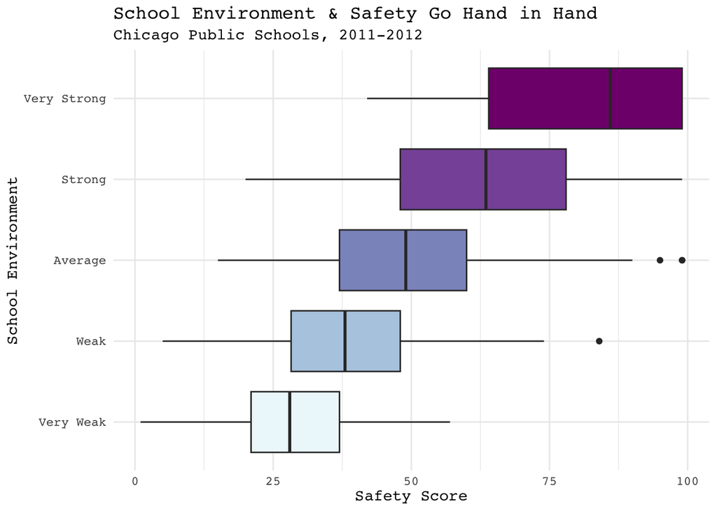

```r
medians <- cs %>% # similar to question above, store calculated medians separately
  select(safety_score, environment_icon) %>%
  group_by(environment_icon) %>%
  summarize(med_safety=median(safety_score))

q9 <- merge(cs, medians) %>% # merge medians, then drop NDA observations so that each observation includes the median for its respective category
  filter(environment_icon != "NDA")

# plot safety by environment, reordered by the median safety measure. Use the median for fill as well to highlight the gradual shift as the categorical features for environment change
ggplot(q9, aes(x=safety_score, y=reorder(environment_icon, med_safety), fill=as.factor(med_safety))) +
  geom_boxplot(na.rm=TRUE) + # remove outliers
  labs(x="Safety Score", y="School Environment", title="School Environment & Safety Go Hand in Hand",
       subtitle="Chicago Public Schools, 2011-2012") +
  theme_minimal() +
  theme(legend.position="none", text=element_text(family='mono')) + # change font family and remove legend
    scale_fill_brewer(palette="BuPu") # choose a palette that indicates categories are related, but distinct values
```

#### Family Involvement & School Safety

Comparing the safety and environmental scores of schools, we find a clear trend in which schools with Very Strong Family Involvement scores tends to score higher in both categories. Only one school with Very Strong Family Involvement is not in the upper-half of scores for both features.

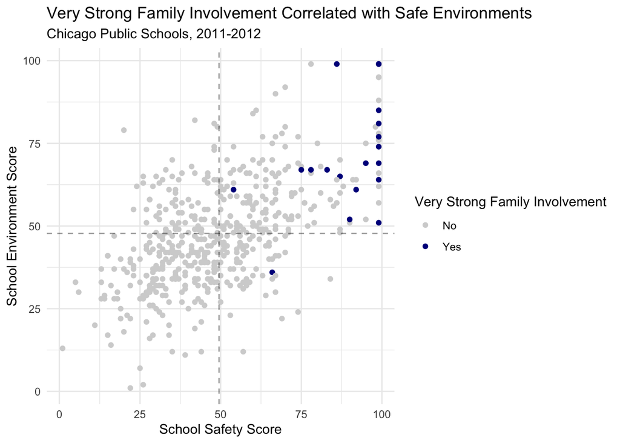

```r
# transform discrete variable to binary for filtering
q10 <- cs %>%
  mutate(strong_family = ifelse(family_involvement_icon=="Very Strong","Yes", "No"))

# plot safety and environment, highlight the newly created binary variable
ggplot(q10, aes(x=safety_score, y=environment_score, color=strong_family)) +
  geom_point(na.rm=TRUE) +
  # scale color so that only binary output of interest is visually highlighted
  scale_color_manual(values=c("lightgrey", "darkblue"), name="Very Strong Family Involvement") +
  # create dashed lines that show x and y axis averages
  geom_hline(yintercept=mean(q10$environment_score, na.rm=TRUE), linetype = 'dashed', alpha=.4) +
  geom_vline(xintercept=mean(q10$safety_score, na.rm=TRUE), linetype='dashed', alpha=.4) +
  labs(x="School Safety Score",y="School Environment Score", title="Very Strong Family Involvement Correlated with Safe Environments", subtitle="Chicago Public Schools, 2011-2012") +
  theme_minimal()
```